# Chapter 10 Regularization Methods

2022-04-23

This notebook illustrates how to implement regularization methods using R.

# Load R Packages

```r
# install packages from CRAN
p_needed <- c('caret', 'elasticnet', 'glmnet', 'devtools',
              'MASS', 'grplasso')

packages <- rownames(installed.packages())
p_to_install <- p_needed[!(p_needed %in% packages)]
if (length(p_to_install) > 0) {
    install.packages(p_to_install)
}

lapply(p_needed, require, character.only = TRUE)

# install packages from GitHub
p_needed_gh <- c('NetlifyDS')

if (! p_needed_gh %in% packages) {
    devtools::install_github("netlify/NetlifyDS")
}

library(NetlifyDS)
```

# Ridge Regression

```r
dat <- read.csv("http://bit.ly/2P5gTw4")
# data cleaning: delete wrong observations
# expense can't be negative
dat <- subset(dat, store_exp > 0 & online_exp > 0)

# get predictors
trainx <- dat[ , grep("Q", names(dat))]
# get response
trainy <- dat$store_exp + dat$online_exp
```

In Ridge regression, there is a tuning parameter $\lambda$ that needs to set for the right level of regularization. The value of lambda can be determined by looking at the performance in the cross-validation data.

```r
# set cross validation
ctrl <- trainControl(method = "cv", number = 10)
# set the parameter range
ridgeGrid <- data.frame(.lambda = seq(0, .1, length = 20))
set.seed(100)

ridgeRegTune <- train(trainx, trainy,
                      method = "ridge",
                      tuneGrid = ridgeGrid,
                      trControl = ctrl,
                      ## center and scale predictors
                      preProc = c("center", "scale"))
ridgeRegTune
```

```
## Ridge Regression
##
## 999 samples
##  10 predictor
##
## Pre-processing: centered (10), scaled (10)
## Resampling: Cross-Validated (10 fold)
## Summary of sample sizes: 899, 899, 899, 899, 899, 900, ...
## Resampling results across tuning parameters:
##
##   lambda       RMSE      Rsquared   MAE
##   0.000000000  1620.980  0.8271792  756.8867
##   0.005263158  1620.079  0.8273987  757.8206
##   0.010526316  1619.773  0.8275476  758.9396
##   0.015789474  1619.901  0.8276512  760.1890
##   0.021052632  1620.366  0.8277243  761.5209
##   0.026315789  1621.107  0.8277760  763.1556
##   0.031578947  1622.083  0.8278122  764.8858
##   0.036842105  1623.267  0.8278370  766.7312
##   0.042105263  1624.639  0.8278529  768.6860
##   0.047368421  1626.185  0.8278620  770.7971
##   0.052631579  1627.892  0.8278657  772.9889
##   0.057894737  1629.753  0.8278649  775.2529
##   0.063157895  1631.760  0.8278605  777.6964
##   0.068421053  1633.908  0.8278530  780.2181
##   0.073684211  1636.190  0.8278430  782.8435
##   0.078947368  1638.604  0.8278307  785.5305
##   0.084210526  1641.144  0.8278165  788.2773
##   0.089473684  1643.808  0.8278006  791.2583
##   0.094736842  1646.592  0.8277832  794.3876
##   0.100000000  1649.494  0.8277644  797.5885
##
## RMSE was used to select the optimal model using the smallest value.
## The final value used for the model was lambda = 0.01052632.
```

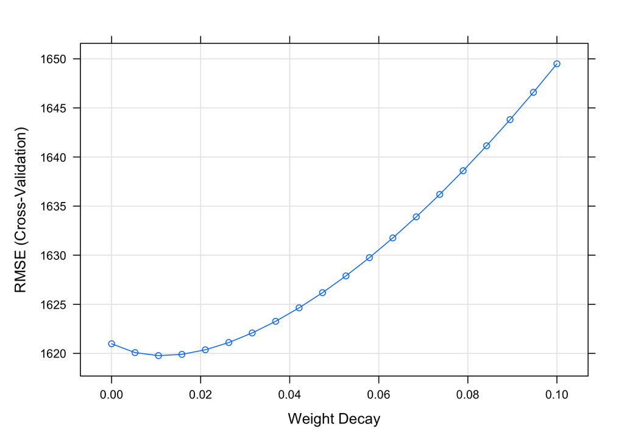

```r
plot(ridgeRegTune)
```

Once we have determined the value for tuning parameter lambda, we can use different ways to fit the ridge regression model, for example, using `enet()` function.

```r
ridgefit = enet(x = as.matrix(trainx), y = trainy, lambda = 0.01,
                # center and scale predictors
                normalize = TRUE)
```

Once the model is fit, we can use the `predict()` function to predict new dataset.

```r
ridgePred <- predict(ridgefit, newx = as.matrix(trainx),
                     s = 1, mode = "fraction", type = "fit")
```

```r
names(ridgePred)
```

```
## [1] "s"        "fraction" "mode"     "fit"
```

```r
head(ridgePred$fit)
```

```
##         1         2         3         4         5         6
## 1290.4697  224.1595  591.4406 1220.6384  853.3572  908.2040
```

```r
ridgeCoef<-predict(ridgefit,newx = as.matrix(trainx),
                   s=1, mode="fraction", type="coefficients")
ridgeCoef$coefficients
```

```
##          Q1          Q2          Q3          Q4          Q5          Q6
## -316.763403  684.044587  649.176319  246.932116  576.078371  692.149705
##          Q7          Q8          Q9         Q10
##    6.181062 -116.500992  382.265663 -314.739623
```

# LASSO

LASSO method will shrink certain parameters to be zero which can be used as a variable selection tool. In LASSO, there is also a tuning parameter called fraction which can be determined by performance of the cross validation data set.

```r
ctrl <- trainControl(method = "cv", number = 10)
lassoGrid <- data.frame(fraction = seq(.8, 1, length = 20))
set.seed(100)
lassoTune <- train(trainx, trainy,
                   ## set the method to be lasso
                   method = "lars",
                   tuneGrid = lassoGrid,
                   trControl = ctrl,
                   ## standardize the predictors
                   preProc = c("center", "scale"))
lassoTune
```

```
## Least Angle Regression
##
## 999 samples
##  10 predictor
##
## Pre-processing: centered (10), scaled (10)
## Resampling: Cross-Validated (10 fold)
## Summary of sample sizes: 899, 899, 899, 899, 899, 900, ...
## Resampling results across tuning parameters:
##
##   fraction   RMSE      Rsquared   MAE
##   0.8000000  1633.994  0.8250185  788.8895
##   0.8105263  1631.956  0.8253421  785.7150
##   0.8210526  1630.196  0.8256225  782.6543
##   0.8315789  1628.441  0.8258906  779.6467
##   0.8421053  1626.539  0.8261791  776.6017
##   0.8526316  1624.745  0.8264526  773.6821
##   0.8631579  1623.107  0.8267066  771.0365
##   0.8736842  1621.643  0.8269375  768.4821
##   0.8842105  1620.390  0.8271378  766.0623
##   0.8947368  1619.349  0.8273079  763.8790
##   0.9052632  1618.520  0.8274481  761.9152
##   0.9157895  1617.903  0.8275585  760.2604
##   0.9263158  1617.516  0.8276338  758.9376
##   0.9368421  1617.382  0.8276544  757.8210
##   0.9473684  1617.452  0.8276476  757.0097
##   0.9578947  1617.802  0.8276001  756.4950
##   0.9684211  1618.367  0.8275239  756.1559
##   0.9789474  1619.138  0.8274210  756.0236
##   0.9894737  1620.048  0.8273066  756.3794
##   1.0000000  1620.980  0.8271792  756.8867
##
## RMSE was used to select the optimal model using the smallest value.
## The final value used for the model was fraction = 0.9368421.
```

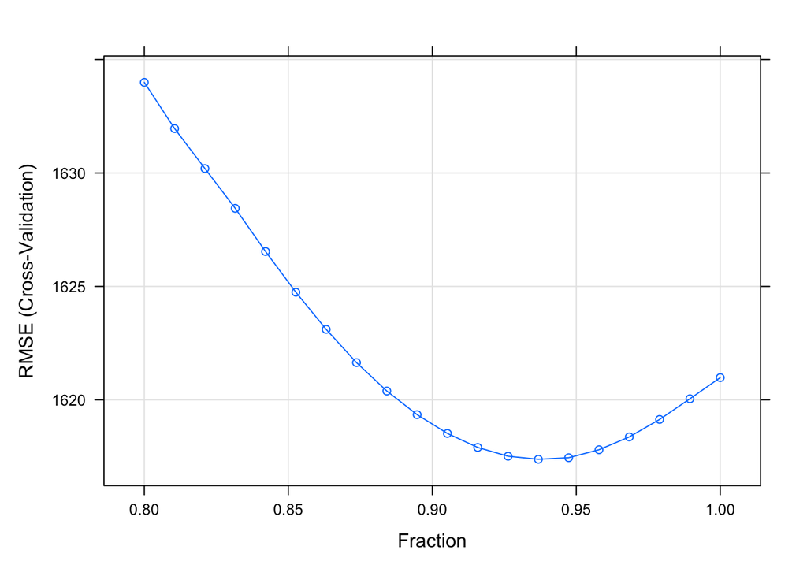

```r
plot(lassoTune)
```

Once the tuning parameter fraction is set, we can use different functions to fit LASSO model, such as `lars()` in `lars`, `enet()` in `elasticnet`, and `glmnet()` in `glmnet`.

```r
lassoModel <- enet(x = as.matrix(trainx), y = trainy,
                  lambda = 0, normalize = TRUE)
```

```r
lassoFit <- predict(lassoModel, newx = as.matrix(trainx),
                    s = 0.957, mode = "fraction", type = "fit")
```

```r
head(lassoFit$fit)
```

```
##         1         2         3         4         5         6
## 1357.2815  300.5298  690.2390 1228.1558  838.4467 1010.0713
```

```r
lassoCoef <- predict(lassoModel,
                     newx = as.matrix(trainx),
                     s = 0.95, mode = "fraction",
                     type = "coefficients")
lassoCoef$coefficients
```

```
##        Q1        Q2        Q3        Q4        Q5        Q6        Q7        Q8
## -326.7759  720.2801  722.7518  180.7107  542.1603  603.0865    0.0000  -75.9610
##        Q9       Q10
##  342.6375 -281.7818
```

# Elastic Net

Elastic net is a generalization of LASSO and ridge regression. It is a combination of LASSO and ridge regression. For elastic net, there are two tuning parameters called lambda and fraction.

```r
enetGrid <- expand.grid(.lambda = seq(0,0.2,length=20),
                        .fraction = seq(.8, 1, length = 20))
set.seed(100)
enetTune <- train(trainx, trainy,
                  method = "enet",
                  tuneGrid = enetGrid,
                  trControl = ctrl,
                  preProc = c("center", "scale"))
enetTune
```

```
## Elasticnet
##
## 999 samples
##  10 predictor
##
## Pre-processing: centered (10), scaled (10)
## Resampling: Cross-Validated (10 fold)
## Summary of sample sizes: 899, 899, 899, 899, 899, 900, ...
## Resampling results across tuning parameters:
##
##   lambda      fraction   RMSE      Rsquared   MAE
##   0.00000000  0.8000000  1633.994  0.8250185  788.8895
##   0.00000000  0.8105263  1631.956  0.8253421  785.7150
##   0.00000000  0.8210526  1630.196  0.8256225  782.6543
##   0.00000000  0.8315789  1628.441  0.8258906  779.6467
##   0.00000000  0.8421053  1626.539  0.8261791  776.6017
##   0.00000000  0.8526316  1624.745  0.8264526  773.6821
##   0.00000000  0.8631579  1623.107  0.8267066  771.0365
##   0.00000000  0.8736842  1621.643  0.8269375  768.4821
##   0.00000000  0.8842105  1620.390  0.8271378  766.0623
##   0.00000000  0.8947368  1619.349  0.8273079  763.8790
##   0.00000000  0.9052632  1618.520  0.8274481  761.9152
##   0.00000000  0.9157895  1617.903  0.8275585  760.2604
##   0.00000000  0.9263158  1617.516  0.8276338  758.9376
##   0.00000000  0.9368421  1617.382  0.8276544  757.8210
##   0.00000000  0.9473684  1617.452  0.8276476  757.0097
##   0.00000000  0.9578947  1617.802  0.8276001  756.4950
##   0.00000000  0.9684211  1618.367  0.8275239  756.1559
##   0.00000000  0.9789474  1619.138  0.8274210  756.0236
##   0.00000000  0.9894737  1620.048  0.8273066  756.3794
##   0.00000000  1.0000000  1620.980  0.8271792  756.8867
##   0.01052632  0.8000000  1635.826  0.8246536  792.3834
##   0.01052632  0.8105263  1633.554  0.8250088  789.1700
##   0.01052632  0.8210526  1631.502  0.8253351  785.9805
##   0.01052632  0.8315789  1629.488  0.8256497  782.7859
##   0.01052632  0.8421053  1627.400  0.8259707  779.6851
##   0.01052632  0.8526316  1625.519  0.8262635  776.6770
##   0.01052632  0.8631579  1623.789  0.8265383  773.9974
##   0.01052632  0.8736842  1622.231  0.8267914  771.4169
##   0.01052632  0.8842105  1620.827  0.8270245  768.9600
```

[output cut: 360 more lines]

```
##   0.20000000  0.8947368  1670.068  0.8263116  828.0905
##   0.20000000  0.9052632  1674.024  0.8264729  831.4404
##   0.20000000  0.9157895  1678.320  0.8266197  835.0089
##   0.20000000  0.9263158  1682.950  0.8267523  838.8427
##   0.20000000  0.9368421  1687.910  0.8268711  843.0953
##   0.20000000  0.9473684  1693.195  0.8269765  847.6169
##   0.20000000  0.9578947  1698.799  0.8270688  852.2574
##   0.20000000  0.9684211  1704.719  0.8271446  857.0843
##   0.20000000  0.9789474  1710.999  0.8271847  862.1782
##   0.20000000  0.9894737  1717.582  0.8272125  867.6137
##   0.20000000  1.0000000  1723.810  0.8272409  872.8446
##
## RMSE was used to select the optimal model using the smallest value.
## The final values used for the model were fraction = 0.9473684 and lambda
##  = 0.01052632.
```

# Penalized Generalized Linear Model

Adding penalties is a general technique that can be applied to many methods other than linear regression. In this section, we will introduce the penalized generalized linear model using `glmnet()`.

## Introduction to `glmnet` package

The default family option in the function `glmnet()` is `gaussian`. It is the linear regression we discussed so far in this chapter. But the parameterization is a little different in the generalized linear model framework (we have $\alpha$ and $\lambda$). Let’s start from our previous example, using the same training data but `glmnet()` to fit model:

```r
dat <- read.csv("http://bit.ly/2P5gTw4")
# data cleaning: delete wrong observations with expense < 0
dat <- subset(dat, store_exp > 0 & online_exp > 0)
# get predictors
trainx <- dat[, grep("Q", names(dat))]
# get response
trainy <- dat$store_exp + dat$online_exp

glmfit = glmnet(as.matrix(trainx), trainy)
```

We can extract useful information using `plot()` and `print()` function from the fitted model.

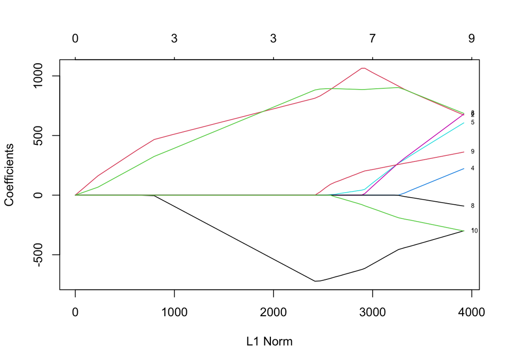

```r
plot(glmfit, label = T)
```

```r
print(glmfit)
```

```
##
## Call:  glmnet(x = as.matrix(trainx), y = trainy)
##
##    Df  %Dev  Lambda
## 1   0  0.00 3042.00
## 2   2 10.38 2771.00
## 3   2 19.19 2525.00
## 4   2 26.50 2301.00
## 5   3 32.64 2096.00
## 6   3 38.94 1910.00
## 7   3 44.17 1741.00
## 8   3 48.52 1586.00
## 9   3 52.12 1445.00
## 10  3 55.12 1317.00
## 11  3 57.60 1200.00
```

[output cut: 57 more lines]

We can also set up the value of $\lambda$ in the LASSO penalty by setting `s` in `coef()` function. For example, the following code set $\lambda$ to be 1200. and there are three coefficients with non-zero estimates(`Q1`, `Q2` and `Q3`).

```r
coef(glmfit, s = 1200)
```

```
## 11 x 1 sparse Matrix of class "dgCMatrix"
##                    s1
## (Intercept) 2255.2221
## Q1          -390.9214
## Q2           653.6437
## Q3           624.4068
## Q4             .
## Q5             .
## Q6             .
## Q7             .
## Q8             .
## Q9             .
## Q10            .
```

You can apply models with different values of tuning parameter to new data using `predict()`:

```r
newdat = matrix(sample(1:9, 30, replace = T), nrow = 3)
predict(glmfit, newdat, s = c(1741, 2000))
```

```
##            s1       s2
## [1,] 4008.107 3795.615
## [2,] 3051.974 3084.707
## [3,] 7099.473 7025.456
```

The tuning parameter $\lambda$ can be determined by the performance of the cross validation data such as the minimum of error or one standard error of the minimum.

```r
cvfit = cv.glmnet(as.matrix(trainx), trainy)
```

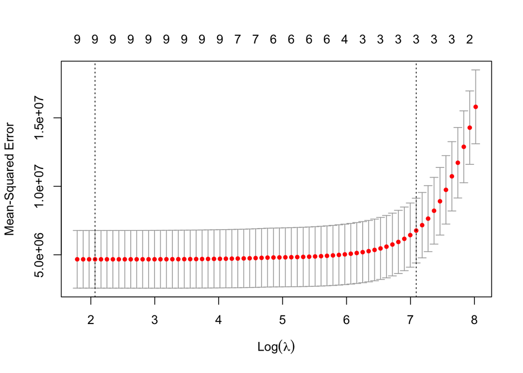

```r
cvfit = cv.glmnet(as.matrix(trainx), trainy)
plot(cvfit)
```

```r
# lambda with minimum mean cross-validated error
cvfit$lambda.min
```

```
## [1] 7.893144
```

```r
# lambda with one standard error of the minimum
cvfit$lambda.1se
```

```
## [1] 1199.688
```

```r
# coefficient estimates for model with the error
# that is within one standard error of the minimum
coef(cvfit, s = "lambda.1se")
```

```
## 11 x 1 sparse Matrix of class "dgCMatrix"
##                    s1
## (Intercept) 2255.3136
## Q1          -391.0562
## Q2           653.7079
## Q3           624.5119
## Q4             .
## Q5             .
## Q6             .
## Q7             .
## Q8             .
## Q9             .
## Q10            .
```

## Penalized Logistic Regression

In this section, we will go over penalized logistic regression using `glmnet()` with “`binomial`” for the “`family`” parameter. Similarly, for the default parameter, it will be LASSO penalty and the tuning parameter can be determined by the performance of the cross validation dataset: minimum of error or one standard error of the minimum.

```r
dat <- read.csv("http://bit.ly/2KXb1Qi")
trainx = dplyr::select(dat, -y)
trainy = dat$y
fit <- glmnet(as.matrix(trainx), trainy, family = "binomial")
```

```r
levels(as.factor(trainy))
```

```
## [1] "0" "1"
```

```r
newdat = as.matrix(trainx[1:3, ])
predict(fit, newdat, type = "link", s = c(2.833e-02, 3.110e-02))
```

```
##           s1         s2
## 1  0.1943472  0.1442796
## 2 -0.9913159 -1.0076600
## 3 -0.5840566 -0.5496074
```

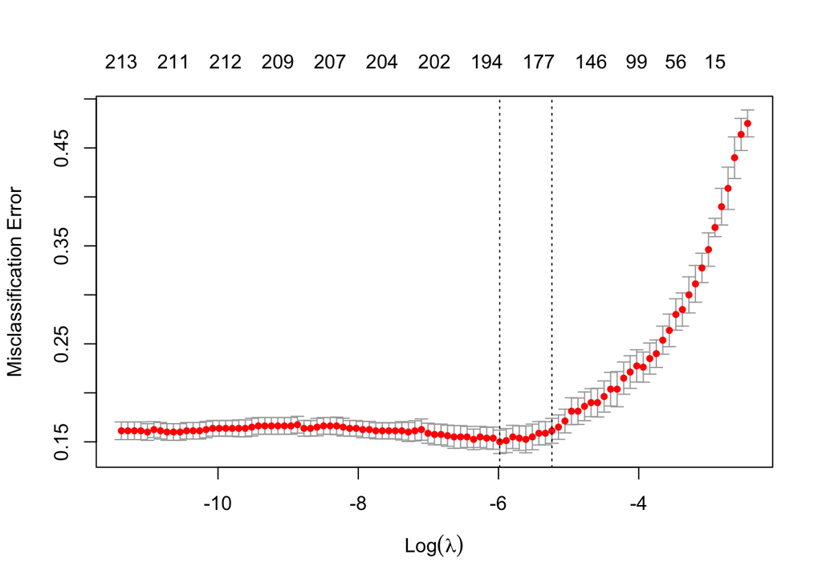

```r
cvfit = cv.glmnet(as.matrix(trainx), trainy,
                 family = "binomial", type.measure = "class")
plot(cvfit)
```

```r
cvfit$lambda.min
```

```
## [1] 0.002522398
```

```r
cvfit$lambda.1se
```

```
## [1] 0.005309407
```

## Group LASSO Logistic Regression

```r
data("sim1_da1")
```

```r
# the last column of sim1_da1 response variable y
# trainx is the explanatory variable matrix
trainx = dplyr::select(sim1_da1, -y)
# save response variable as as trainy
trainy = sim1_da1$y
# get the group indicator
index <- gsub("\\..*", "", names(trainx))
```

```r
index[1:50]
```

```
##  [1] "Q1"  "Q1"  "Q2"  "Q2"  "Q3"  "Q3"  "Q4"  "Q4"  "Q5"  "Q5"  "Q6"  "Q6"
## [13] "Q7"  "Q7"  "Q8"  "Q8"  "Q9"  "Q9"  "Q10" "Q10" "Q11" "Q11" "Q12" "Q12"
## [25] "Q13" "Q13" "Q14" "Q14" "Q15" "Q15" "Q16" "Q16" "Q17" "Q17" "Q18" "Q18"
## [37] "Q19" "Q19" "Q20" "Q20" "Q21" "Q21" "Q22" "Q22" "Q23" "Q23" "Q24" "Q24"
## [49] "Q25" "Q25"
```

```r
# Tune over 100 values
nlam <- 100
# set the type of prediction
# - `link`: return the predicted link function
# - `response`: return the predicted probability
# number of cross-validation folds
kfold <- 10
cv_fit <- cv_glasso(trainx, trainy,
nlam = nlam, kfold = kfold, type = "link")
```

```r
str(cv_fit, width = 60, strict.width = "cut",  list.len = 9)
```

```
## List of 11
##  $ lambda            : num [1:100] 52.5 50.4 48.4 46.4 44...
##  $ pred              :'data.frame':  800 obs. of  100 varia..
##   ..$ X52.4935652246023 : num [1:800] -0.0556 -0.0556 -0.0..
##   ..$ X50.3938226156183 : num [1:800] -0.0556 -0.0556 -0.0..
##   ..$ X48.3780697109935 : num [1:800] -0.0559 -0.0559 -0.0..
##   ..$ X46.4429469225538 : num [1:800] -0.0589 -0.0589 -0.0..
##   ..$ X44.5852290456516 : num [1:800] -0.0617 -0.0617 -0.0..
##   ..$ X42.8018198838256 : num [1:800] -0.06438 -0.06438 -0..
##   ..$ X41.0897470884725 : num [1:800] -0.0729 -0.0417 -0.1..
##   ..$ X39.4461572049336 : num [1:800] -0.08801 -0.00791 -0..
##   ..$ X37.8683109167363 : num [1:800] -0.1092 0.0212 -0.08..
##   .. [list output truncated]
##  $ auc               : num [1:100] 0.573 0.568 0.557 0.518..
##  $ log_likelihood    : num [1:100] -556 -556 -556 -555 -55..
##  $ maxrho            : num [1:100] -0.0492 -0.0306 0.0302 ..
##  $ lambda.max.auc    : Named num [1:2] 0.922 0.949
##   ..- attr(*, "names")= chr [1:2] "lambda" "auc"
##  $ lambda.1se.auc    : Named num [1:2] 16.738 0.828
##   ..- attr(*, "names")= chr [1:2] "" "se.auc"
##  $ lambda.max.loglike: Named num [1:2] 1.57 -233.49
##   ..- attr(*, "names")= chr [1:2] "lambda" "loglike"
##  $ lambda.1se.loglike: Named num [1:2] 9.07 -349.13
##   ..- attr(*, "names")= chr [1:2] "lambda" "se.loglike"
##   [list output truncated]
##  - attr(*, "class")= chr "cv_glasso"
```

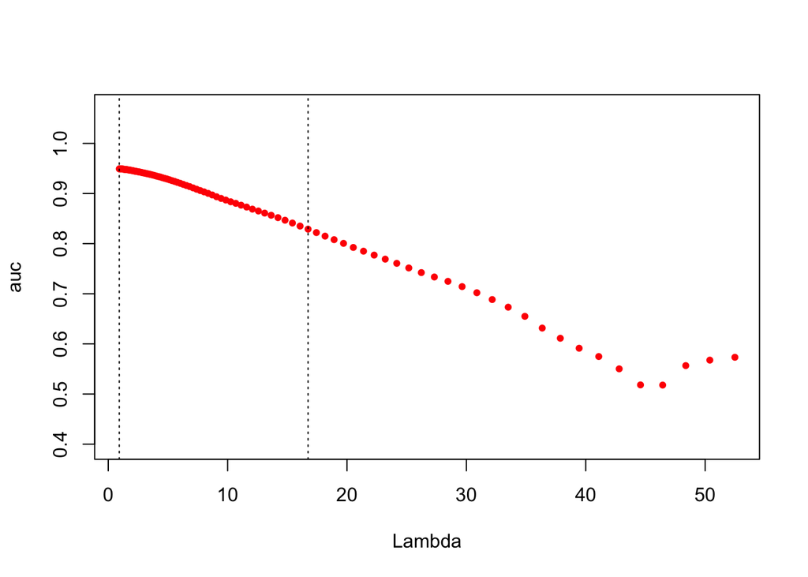

```r
plot(cv_fit)
```

```r
fitgl <- fitglasso(trainx, trainy,
                   lambda = 0.922, na_action = na.pass)
```

```
## Lambda: 0.922  nr.var: 229
```

```r
head(coef(fitgl))
```

```
##                 0.922
## Intercept -53.1803922
## Q1.A        1.7566722
## Q1.B        1.7190500
## Q2.A        2.1699192
## Q2.B        0.6939251
## Q3.A        2.1020142
```

```r
prey <- predict_glasso(fitgl, trainx)
```